# R for Biology Data Science Workshop Series

Faculty of Natural and Agricultural Sciences, University of Pretoria

Joey Hulbert

### Welcome!

The purpose of this page is to provide resources for the *R for Biology Data Science* Workshop Series for postgrad students and postdocs in the [Faculty of Natural and Agricultural Sciences](https://www.up.ac.za/faculty-of-natural-agricultural-sciences) at the [University of Pretoria](https://www.up.ac.za/) in South Africa.

- Workshop Series
  - April 23, 2019.
    - [Session 1 - Introduction to RStudio](http://jmhulbert.github.io/r/bio/s1).
      - Learn the basics of coding, importing data, installing packages, and managing projects.
  - April 30, 2019.
    - [Session 2 - Introduction to data visualization with ggplot2 **Part 1**](http://jmhulbert.github.io/r/bio/s2).
      - Create plots (histograms, boxplots, barplots), faceting, adjustments, etc.
  - May 7, 2019.
    - [Session 3 - Introduction to data visualization with ggplot2 **Part 2**](http://jmhulbert.github.io/r/bio/s3).
      - Customizing plot aesthetics (colors, labels, italics, etc.), saving and exporting.
  - May 14, 2019.
    - **No session offered**
  - May 21, 2019.
    - [Session 4 - Introduction to data transformation with dplyr **Part 1**](http://jmhulbert.github.io/r/bio/s4).
      - Filter data, summarize data (e.g. easily calculate means for groups), add variables.
  - May 28, 2019.
    - [Session 5 - Introduction to data transformation with dplyr **Part 2**](http://jmhulbert.github.io/r/bio/s5).
      - Merge datasets, combine tables, introduction to stringr, introduction to R markdown.

### Pre-workshop instructions

Please check out the [pre-workshop instructions](http://jmhulbert.github.io/r/bio/pre) prior to attending the first workshop (Link coming soon).

## Details

### Schedule

**The first session will only start at 4pm**, all other sessions will start at 3pm.

Please note that there is no session scheduled for May 14th.

##### Google calendar

Here is [a link](https://calendar.google.com/calendar?cid=dXAuYWMuemFfbzR2ZTdmMWk1bzU2dG00bTlkMzNvb20ybGNAZ3JvdXAuY2FsZW5kYXIuZ29vZ2xlLmNvbQ) to the Google calendar for the workshop series. You can add the calendar to your diary.

https://calendar.google.com/calendar?cid=dXAuYWMuemFfbzR2ZTdmMWk1bzU2dG00bTlkMzNvb20ybGNAZ3JvdXAuY2FsZW5kYXIuZ29vZ2xlLmNvbQ

[interactive chart not shown]

### Location

All sessions will be offered in the auditorium of the Forestry and Agricultural Biotechnology Institute (FABI).

##### Directions

The audiotorium is on the bottom floor of the FABI 2 building, but you will need to enter from the FABI 1 building. Head left from the front door and continue to the left (two additional left turns) until you reach the auditorium from the front door.

[interactive chart not shown]

## Participant Information Breakdown

### Department

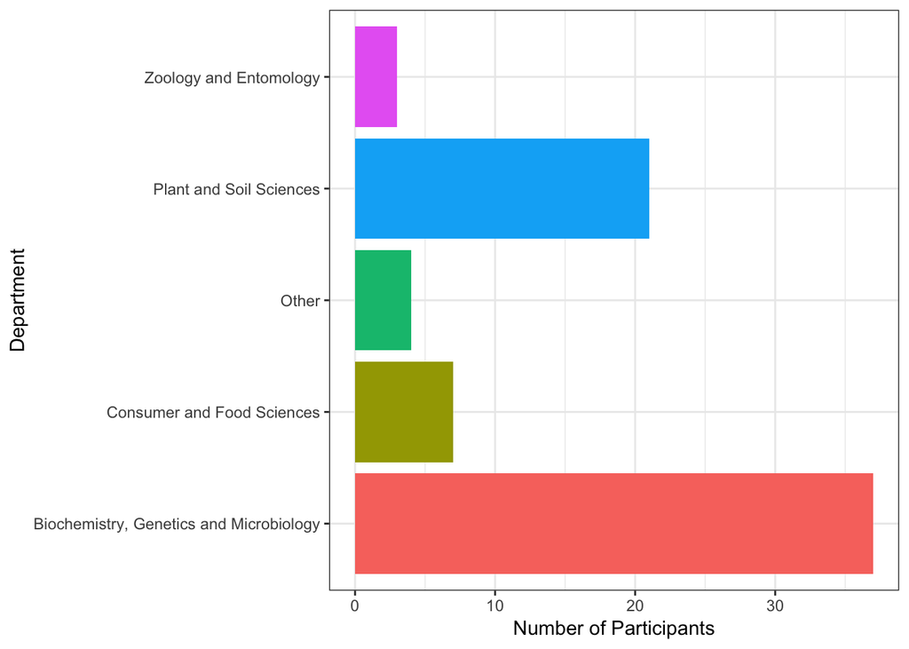

### Academic Standing

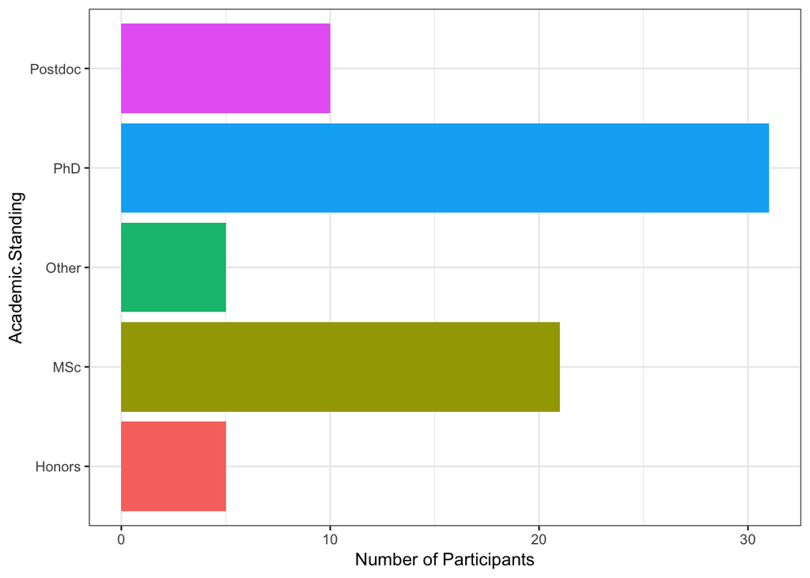

### Year

Year in academic position

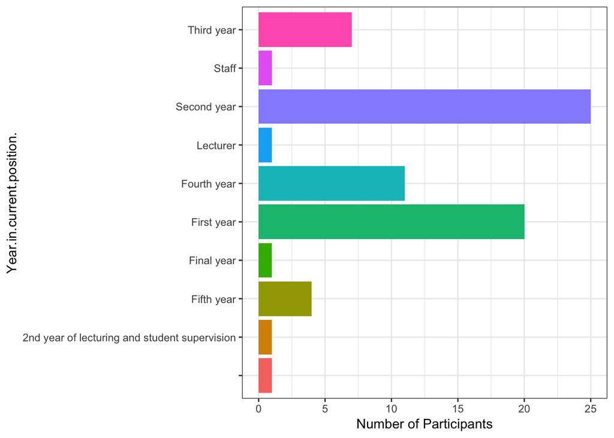

### Data availability

Do you have your own data?

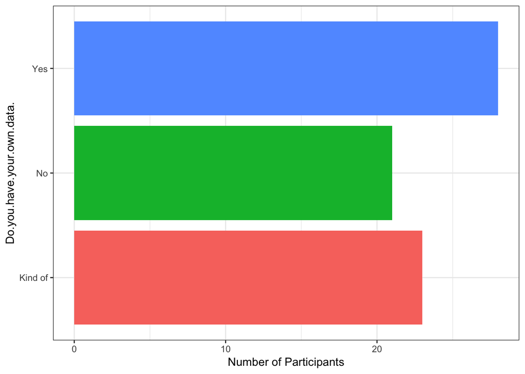

### Computer Availability

Do you have a computer you can bring to the sessions?

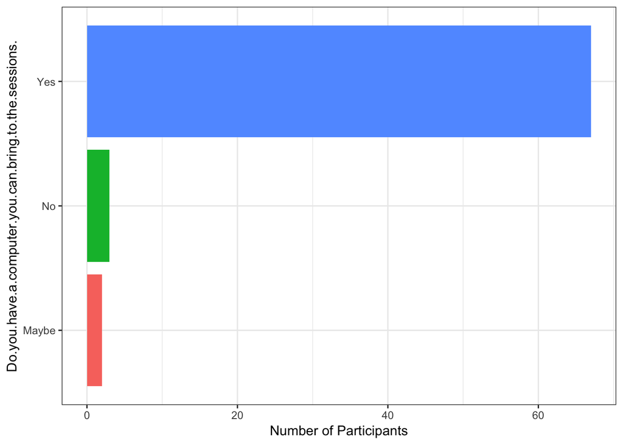

### R Familiarity

Have you used R before?

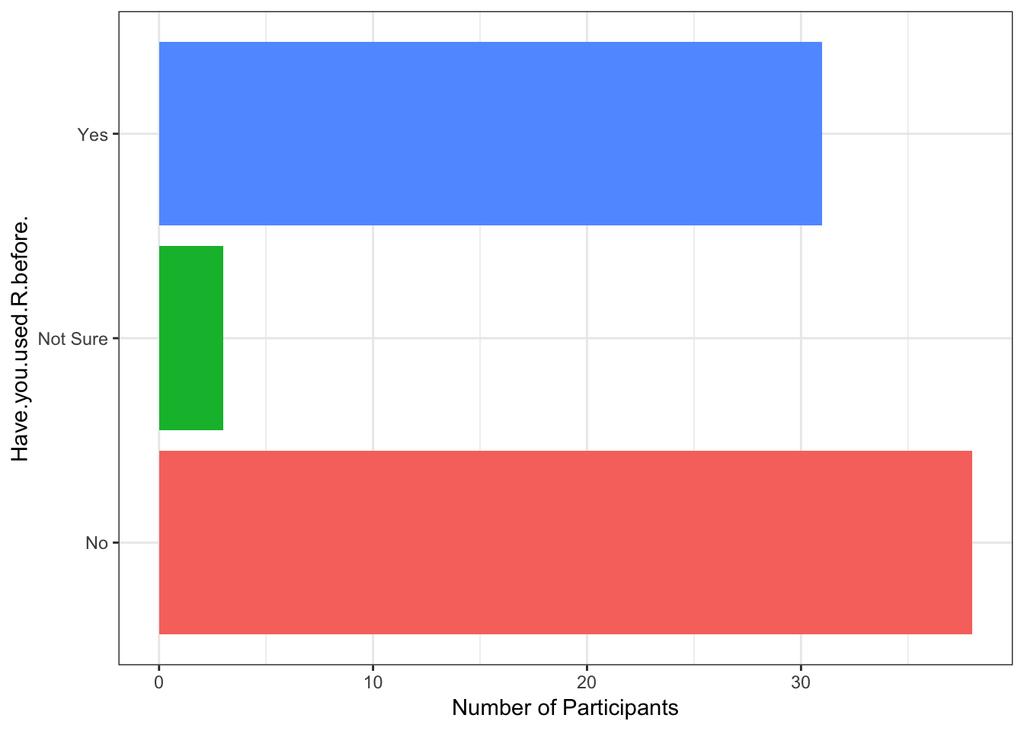

If so, how often? (1=never, 10=everday)

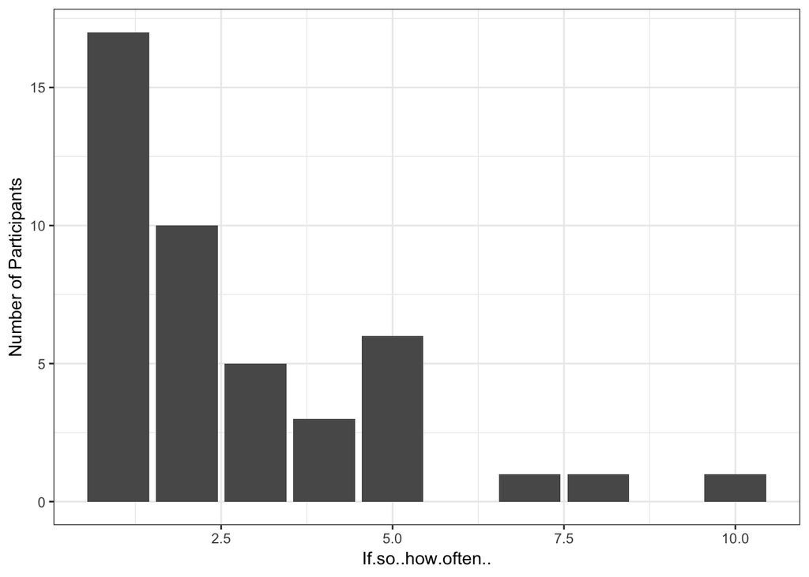